```python
import pandas as pd
```

```python
chessGames = pd.read_csv('Datasets/assignment4.csv', sep=',')
```

# Numerical columns:

- Turns;
- White_rating;
- Black_rating;
- Opening_ply.

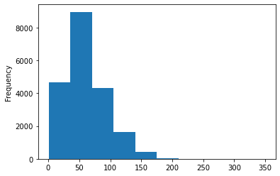

```python
chessGames['turns'].plot.hist(bins=10)
```

Because the turns are countable (they go from 1 to 2, with no value in between) the variable that describes the turns is discrete. This means that the distribution function that is used to describe this variable, must also be discrete. The distributions that were taught in class, the uniform and the normal distributions, are both used to describe continuous variables and thus can not be used for this variable.

Having looked at the other given distributions that might fit, the binomial and the Poisson distributions, it looks like the binomial would be most suitable for this variable. This because the Poisson distribution can be used to describe events happening over time, something which isn't used applicable to this variable.

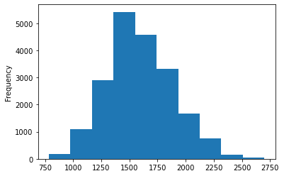

```python
chessGames['white_rating'].plot.hist(bins=10)
```

Because the rating of the player playing with white is countable (it goes from 1 to 2, with no value in between) the variable that describes the rating is discrete. This means that the distribution function that is used to describe this variable, must also be discrete. The distributions that were taught in class, the uniform and the normal distributions, are both used to describe continuous variables and thus can not be used for this variable.

Having looked at the other given distributions that might fit, the binomial and the Poisson distributions, it looks like the binomial would be most suitable for this variable. This because the Poisson distribution can be used to describe events happening over time, something which isn't used applicable to this variable.

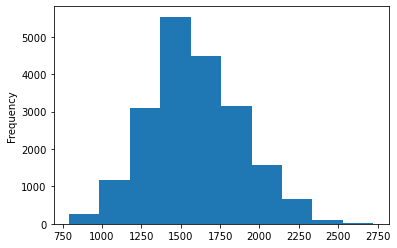

```python
chessGames['black_rating'].plot.hist(bins=10)
```

Because the rating of the player playing with black is countable (it goes from 1 to 2, with no value in between) the variable that describes the rating is discrete. This means that the distribution function that is used to describe this variable, must also be discrete. The distributions that were taught in class, the uniform and the normal distributions, are both used to describe continuous variables and thus can not be used for this variable.

Having looked at the other given distributions that might fit, the binomial and the Poisson distributions, it looks like the binomial would be most suitable for this variable. This because the Poisson distribution can be used to describe events happening over time, something which isn't used applicable to this variable.

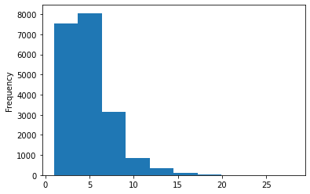

```python
chessGames['opening_ply'].plot.hist(bins=10)
```

Because the opening ply (the number of moves in the opening phase) is dependent on the turns and is thusly countable (it goes from 1 to 2, with no value in between) the variable that describes the opening ply is discrete. This means that the distribution function that is used to describe this variable, must also be discrete. The distributions that were taught in class, the uniform and the normal distributions, are both used to describe continuous variables and thus can not be used for this variable.

Having looked at the other given distributions that might fit, the binomial and the Poisson distributions, it looks like the binomial would be most suitable for this variable. This because the Poisson distribution can be used to describe events happening over time, something which isn't used applicable to this variable.